# Lecture 2 ggplot2的简要介绍

Hongwei Shi

2021-09-15

# 基本介绍

## 参考资料

- [ggplot2: elegant graphics for data analysis](https://ggplot2-book.org/)
- [A Gentle Guide to the Grammar of Graphics with ggplot2 by Garrick Aden-Buie](https://pkg.garrickadenbuie.com/gentle-ggplot2/)
- [Top 50 ggplot2 Visualizations by Selva Prabhakaran](https://r-statistics.co/Top50-Ggplot2-Visualizations-MasterList-R-Code.html)

## ggplot2的安装

- **Easy**: install the tidyverse `install.packages("tidyverse")`

> Tidyverse是一系列R包的集合，包含了dplyr、ggplot2、tidyr、stringr等，从数据导入预处理，再到高级转化、可视化、建模和展示。因为其代码清晰可读的编程风格，得到越来越多人的喜爱。
- **Medium**: install just ggplot2 `install.packages("ggplot2")`
- **Expert**: install from GitHub `devtools::install_github("tidyverse/ggplot2")`

## 为什么选择ggplot2

- ggplot2 最初是 RStudio 首席科学家 [Hadley Wickham](http://hadley.nz/) 在2005年读博士期间的作品。看下2020年至今 ggplot2 的下载量！

```r
library(cranlogs)
d <- cran_downloads(package="ggplot2", from="2020-01-01", to="2021-09-01")
sum(d$count)
```

```
## [1] 31611548
```

- ggplot2 有一套优雅的绘图语法，包名中 “gg” 是 grammar of graphics 的简称。Hadley Wickham将这套可视化语法诠释为: 一张统计图形就是从数据到几何图形 (geometric object，缩写geom) 所包含的图形属性 (aesthetic attribute，缩写 “aes”) 的一种映射。
- ggplot2 是十分方便的统计作图工具，相比 Base R，为了一张出版级的图形，不需要去调整每个参数，实现快速出图。集成了很多其它统计计算的 R 包，支持丰富的统计分析和计算功能，如回归、平滑等，实现了作图和模型的无缝连接。

# ggplot2：稳健回归可视化

## 基本语法介绍

ggplot2的使用：将一个作图任务分解为若干个子任务，只要完成各个子任务就可以完成作图。

- 将图形所展现的数据输入到 `ggplot()` 函数中。
- 然后调用某个 `geom_xxx()` 函数，指定图形类型，如散点图、曲线图、箱线图等。
- 调用其它函数，添加亿点点细节。控制变量的表现形式，修改配色、形状、添加标签、调整坐标、调整标签位置、修改主题等。

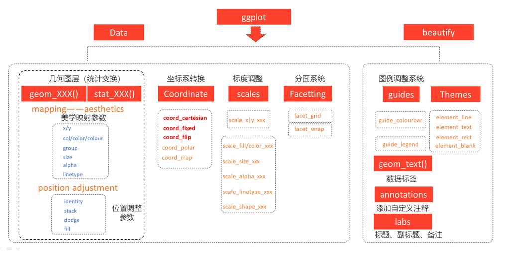

```r
p <- ggplot(data=<输入数据框>,
            mapping=aes(<维度>=<变量名>, <维度>=<变量名>, <...>))
p + geom_<图形类型>(<...>) +
  scale_<映射>_<类型>(<...>) +
  coord_<类型>(<...>) +
  labs(<...>)
```

数据类型：R语言数据类型有字符串型、数值型、因子型、逻辑型、日期型等。我们在而呈现数据的时候，可能会同时用到多种类型的数据。

- ggplot2会将字符串型、因子型、逻辑型、日期型默认为离散变量
- 数值型默认为连续变量。

多图排版参考链接：[ggplot2一页多图排版的简便方法](https://www.jianshu.com/p/c154ca35530b)，细节用法可以自由探索！

- patchwork 修改图形布局
- ggpubr 中的 `ggarrange()`，实现多图排版
- cowplot 中的 `plot_grid()`
- gridExtra 中的 `grid.arrange()`

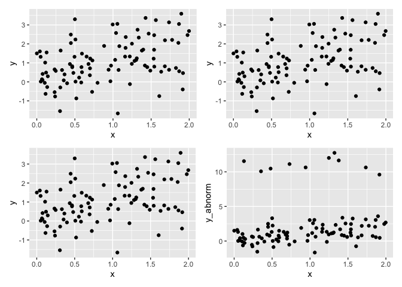

```r
library(tidyverse)
library(patchwork)
library(ggpubr)
library(cowplot)
library(gridExtra)

## 稳健回归
n <- 100; beta <- 1; error <- rnorm(100)
x <- runif(n, 0, 2); xsort <- sort(x) # 对x进行排序
y <- beta*xsort + error
outliers.pos <- sample(1:n, floor(0.1*n)) # 在y方向上构造离群点
y.abnorm <- y; y.abnorm[outliers.pos] <- y.abnorm[outliers.pos] + 10
outliers.label <- rep("norm", n); outliers.label[outliers.pos] <- "abnorm"
df.plot <- data.frame(x=xsort,
                      y=y,
                      y_abnorm=y.abnorm,
                      outliers_label=outliers.label)

# 散点图
p1 <- ggplot(data=df.plot, mapping=aes(x=x, y=y)) +
  geom_point()
p11 <- df.plot %>% ggplot(aes(x, y)) +
  geom_point()
p2 <- ggplot() +
  geom_point(data=df.plot, aes(x, y))
p22 <- df.plot %>% ggplot() +
  geom_point(aes(x, y_abnorm))
(p1 + p11) / (p2 + p22)
```

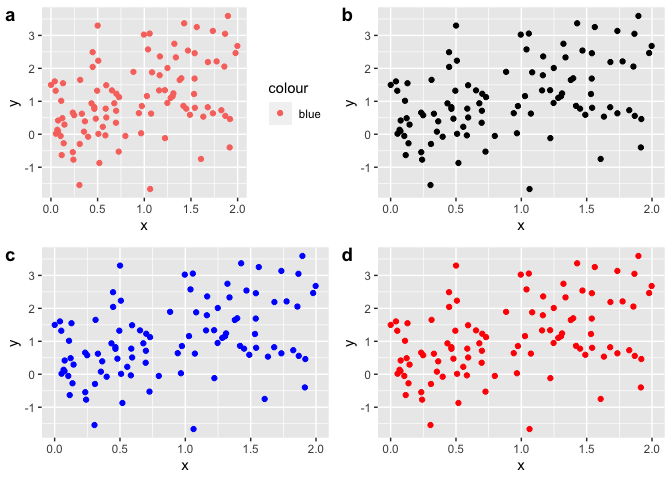

```r
# 修改散点颜色
p3 <- df.plot %>% ggplot(aes(x, y, color="blue")) +
  geom_point() # 这样对吗？
p4 <- df.plot %>% ggplot(aes(x, y), color="blue") +
  geom_point()
p5 <- df.plot %>% ggplot(aes(x=x, y=y)) +
  geom_point(color="blue")
p6 <- df.plot %>% ggplot(aes(x, y), color="blue") +
  geom_point(color="red")
ggarrange(p3, p4, p5, p6,
          labels=c("a", "b", "c", "d"),
          ncol=2, nrow=2)
```

> `ggplot()` 中为全局声明；`geom_xxx()` 中为局部声明。这取决于你想要实现什么要的可视化，怎么方便怎么来！

`aes()` 中添加颜色标签的作用是什么？ - `aes()` 除了位置上映射，还可以实现色彩、形状或透明度等视觉属性的映射

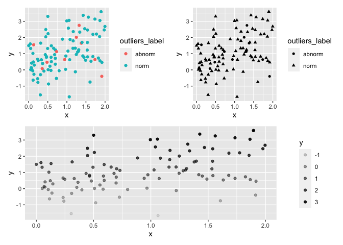

```r
# 实现不同颜色分组
p1 <- df.plot %>%
  ggplot(aes(x, y, color=outliers_label)) +
  geom_point()
# 不同形状分组
p2 <- df.plot %>%
  ggplot(aes(x, y, shape=outliers_label)) +
  geom_point()
# 不同透明度分组
p3 <- df.plot %>%
  ggplot(aes(x, y, alpha=y)) +
  geom_point()
(p1 + p2)/ p3
```

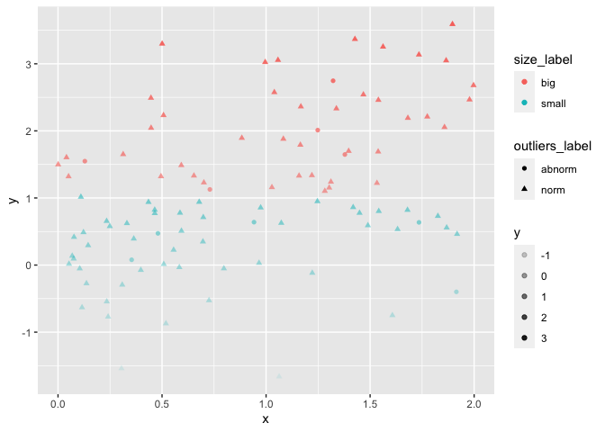

```r
# 也可以实现更多映射
df.plot %>%
  mutate(size_label=ifelse(y>=mean(y), "big", "small")) %>%
  ggplot(aes(x, y, color=size_label, shape=outliers_label, alpha=y)) +
  geom_point()
```

## 增加亿点点细节

### 多组数据集能否展示在一张图上呢？

- 将异常点和正常点展示在一张图上，通过不同颜色显示

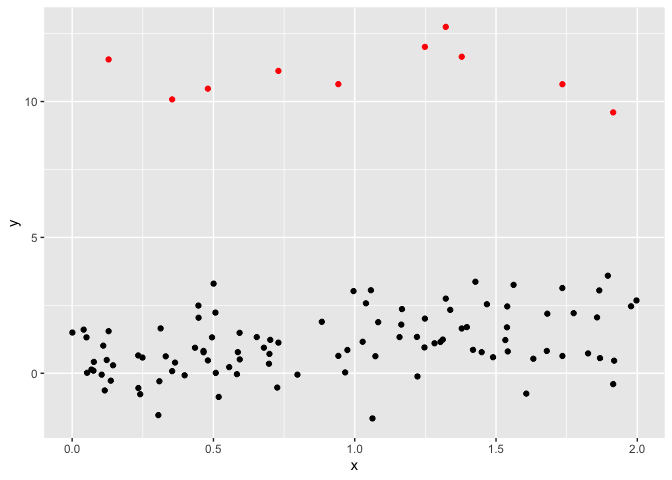

```r
df.abnorm <- data.frame(x=xsort[outliers.pos], y=y.abnorm[outliers.pos])
ggplot() +
  geom_point(data=df.plot, aes(x, y), color="black") +
  geom_point(data=df.abnorm, aes(x, y), color="red")
```

### 标签

- 参考链接：[ggplot2之标度](https://bookdown.org/wangminjie/R4DS/ggplot2-scales.html)
- 为异常点和正常点添加标签

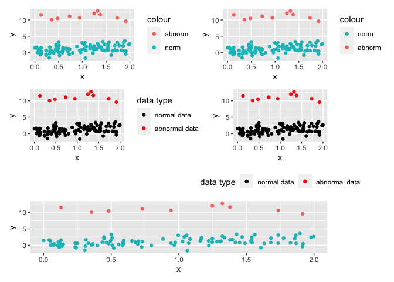

```r
p1 <- ggplot() +
  geom_point(data=df.plot, aes(x, y, color="norm")) +
  geom_point(data=df.abnorm, aes(x, y, color="abnorm"))

# 修改标签名称
p2 <- p1 + scale_colour_hue(breaks=c("norm", "abnorm"))
p3 <- p1 + scale_colour_manual(name="data type",
                     values=c("norm"="black", "abnorm"="red"),
                     labels=c("normal data", "abnormal data"))
# 修改标签位置
p4 <- p3 + theme(legend.position="bottom")

# 去除标签
p5 <- p1 + scale_colour_hue(guide="none")
(p1 + p2) / (p3 + p4) / p5
```

### 注释

- 为异常点添加文字注释

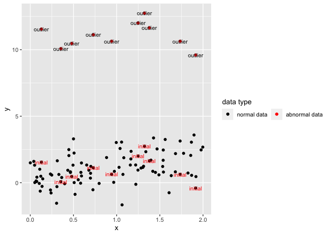

```r
library(ggrepel)
ggplot() +
  geom_point(data=df.abnorm, aes(x, y, color="abnorm")) +
  geom_point(data=df.plot, aes(x, y, color="norm")) +
  scale_colour_manual(name="data type",
                     values=c("norm"="black", "abnorm"="red"),
                     labels=c("normal data", "abnormal data")) +
  guides(color=guide_legend(ncol=2)) + # 修改标签布局
  annotate(geom='text', label="outlier", x=df.abnorm$x, y=df.abnorm$y, size=3) + # 添加文本标注
  annotate(geom='text', label="initial", color="red",
           x=df.plot$x[outliers.pos], y=df.plot$y[outliers.pos], size=3)
```

**可以尝试将正常点和异常点用不同形状表示**

### 坐标

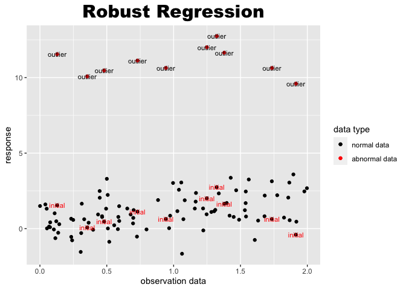

```r
ggplot() +
  geom_point(data=df.abnorm, aes(x, y, color="abnorm")) +
  geom_point(data=df.plot, aes(x, y, color="norm")) +
  scale_colour_manual(name="data type",
                     values=c("norm"="black", "abnorm"="red"),
                     labels=c("normal data", "abnormal data")) +
  annotate(geom='text', label="outlier", x=df.abnorm$x, y=df.abnorm$y, size=3) + # 添加文本标注
  annotate(geom='text', label="initial", color="red",
           x=df.plot$x[outliers.pos], y=df.plot$y[outliers.pos], size=3) +
  labs(x="observation data", y="response", title="Robust Regression") +
  # ggtitle() + xlab() + ylab() +
  theme(plot.title=element_text(family="Arial-Black", size=rel(2), hjust=0.5), # 标题居中显示
        axis.title=element_text(size=rel(1)))
```

### 主题

```r
ls("package:ggplot2", pattern = "^theme_")
```

```
##  [1] "theme_bw"       "theme_classic"  "theme_dark"     "theme_get"
##  [5] "theme_gray"     "theme_grey"     "theme_light"    "theme_linedraw"
##  [9] "theme_minimal"  "theme_replace"  "theme_set"      "theme_test"
## [13] "theme_update"   "theme_void"
```

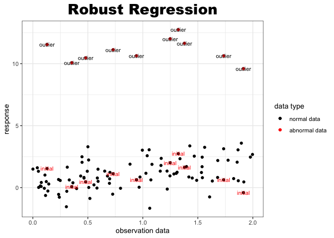

```r
ggplot() +
  geom_point(data=df.abnorm, aes(x, y, color="abnorm")) +
  geom_point(data=df.plot, aes(x, y, color="norm")) +
  scale_colour_manual(name="data type",
                     values=c("norm"="black", "abnorm"="red"),
                     labels=c("normal data", "abnormal data")) +
  annotate(geom='text', label="outlier", x=df.abnorm$x, y=df.abnorm$y, size=3) + # 添加文本标注
  annotate(geom='text', label="initial", color="red",
           x=df.plot$x[outliers.pos], y=df.plot$y[outliers.pos], size=3) +
  labs(x="observation data", y="response", title="Robust Regression") +
  # ggtitle() + xlab() + ylab() +
  theme_bw() + # 注意自带主题和自定义主题的前后顺序
  theme(plot.title=element_text(family="Arial-Black", size=rel(2), hjust=0.5), # 标题居中显示
        axis.title=element_text(size=rel(1)))
```

## 最小二乘回归与稳健回归方法对比

- 对比绝对值 loss 和 huber loss 的结果

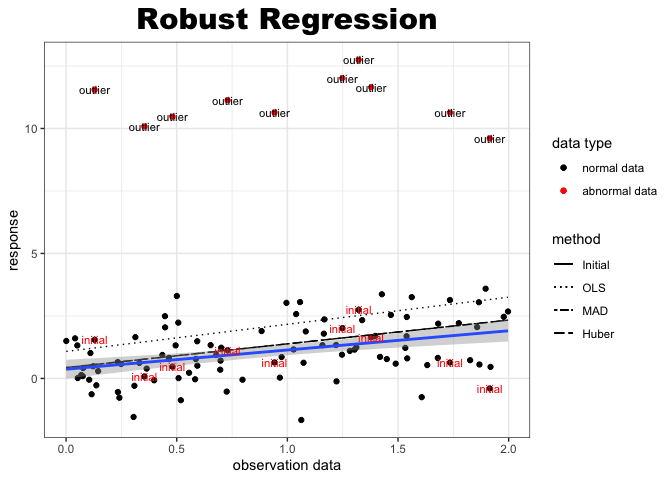

[figure not shown]

```r
library(MASS)
lm.true <- lm(y~x, data=df.plot)
y.true <- lm.true$coefficients[1] + lm.true$coefficients[2]*xsort
lm.ols <- lm(y_abnorm~x, data=df.plot)
y.ols <- lm.ols$coefficients[1] + lm.ols$coefficients[2]*xsort
lm.abs <- rlm(y_abnorm~x, data=df.plot, scale.est="MAD", method="M")
y.abs <- lm.abs$coefficients[1] + lm.abs$coefficients[2]*xsort
lm.huber <- rlm(y_abnorm~x, data=df.plot, scale.est="Huber", method="M")
y.huber <- lm.huber$coefficients[1] + lm.huber$coefficients[2]*xsort

df.plot <- df.plot %>% mutate(y_true=y.true, y_ols=y.ols,
                              y_abs=y.abs, y_huber=y.huber)

ggplot() +
  geom_point(data=df.abnorm, aes(x, y, color="abnorm")) +
  geom_point(data=df.plot, aes(x, y, color="norm")) +
  geom_line(data=df.plot, aes(x, y_true, linetype="solid")) +
  geom_line(data=df.plot, aes(x, y_ols, linetype="dotted")) +
  geom_line(data=df.plot, aes(x, y_abs, linetype="twodash")) +
  geom_line(data=df.plot, aes(x, y_huber, linetype="longdash")) +
  geom_smooth(data=df.plot, aes(x, y), method = "lm") + # 添加平滑曲线
  scale_colour_manual(name="data type",
                     values=c("norm"="black", "abnorm"="red"),
                     labels=c("normal data", "abnormal data")) +
  scale_linetype_manual(name="method",
                        values=c("solid"="solid", "dotted"="dotted", "twodash"="twodash", "longdash"="longdash"),
                        labels=c("Initial", "OLS", "MAD", "Huber")) +
  annotate(geom='text', label="outlier", x=df.abnorm$x, y=df.abnorm$y, size=3) + # 添加文本标注
  annotate(geom='text', label="initial", color="red",
           x=df.plot$x[outliers.pos], y=df.plot$y[outliers.pos], size=3) +
  labs(x="observation data", y="response", title="Robust Regression") +
  # ggtitle() + xlab() + ylab() +
  theme_bw() + # 注意自带主题和自定义主题的前后顺序
  theme(plot.title=element_text(family="Arial-Black", size=rel(2), hjust=0.5), # 标题居中显示
        axis.title=element_text(size=rel(1)))
```